# Fitbit Analyze

Chung-Yu Su

2023-04-18

## Introduction

Case Study 2: How Can a Wellness Technology Company Play It Smart? Welcome to the Bellabeat data analysis case study! In this case study, you will perform many real-world tasks of a junior data analyst. You will imagine you are working for Bellabeat, a high-tech manufacturer of health-focused products for women, and meet different characters and team members. In order to answer the key business questions, you will follow the steps of the data analysis process: ask, prepare, process, analyze, share, and act. Along the way, the Case Study Roadmap tables — including guiding questions and key tasks — will help you stay on the right path. By the end of this lesson, you will have a portfolio-ready case study. Download the packet and reference the details of this case study anytime. Then, when you begin your job hunt, your case study will be a tangible way to demonstrate your knowledge and skills to potential employers. ## Scenario You are a junior data analyst working on the marketing analyst team at Bellabeat, a high-tech manufacturer of health-focused products for women. Bellabeat is a successful small company, but they have the potential to become a larger player in the global smart device market. Urška Sršen, cofounder and Chief Creative Officer of Bellabeat, believes that analyzing smart device fitness data could help unlock new growth opportunities for the company. You have been asked to focus on one of Bellabeat’s products and analyze smart device data to gain insight into how consumers are using their smart devices. The insights you discover will then help guide marketing strategy for the company. You will present your analysis to the Bellabeat executive team along with your high-level recommendations for Bellabeat’s marketing strategy.

## Characters and products

### ● Characters

○ Urška Sršen: Bellabeat’s cofounder and Chief Creative Office  
○ Sando Mur: Mathematician and Bellabeat’s cofounder; key member of the Bellabeat executive team  
○ Bellabeat marketing analytics team: A team of data analysts responsible for collecting, analyzing, andreporting data that helps guide Bellabeat’s marketing strategy. You joined this team six months ago and have been busy learning about Bellabeat’’s mission and business goals — as well as how you, as a junior data analyst, can help Bellabeat achieve them.

### ● Products

○ Bellabeat app: The Bellabeat app provides users with health data related to their activity, sleep, stress,menstrual cycle, and mindfulness habits. This data can help users better understand their current habits andmake healthy decisions. The Bellabeat app connects to their line of smart wellness products.  
○ Leaf: Bellabeat’s classic wellness tracker can be worn as a bracelet, necklace, or clip. The Leaf tracker connectsto the Bellabeat app to track activity, sleep, and stress.  
○ Time: This wellness watch combines the timeless look of a classic timepiece with smart technology to track user activity, sleep, and stress. The Time watch connects to the Bellabeat app to provide you with insights into your daily wellness.  
○ Spring: This is a water bottle that tracks daily water intake using smart technology to ensure that you areappropriately hydrated throughout the day. The Spring bottle connects to the Bellabeat app to track your hydration levels.  
○ Bellabeat membership: Bellabeat also offers a subscription-based membership program for users. Membership gives users 24/7 access to fully personalized guidance on nutrition, activity, sleep, health and beauty, and mindfulness based on their lifestyle and goals.

## About the company

Urška Sršen and Sando Mur founded Bellabeat, a high-tech company that manufactures health-focused smart products. Sršen used her background as an artist to develop beautifully designed technology that informs and inspires women around the world. Collecting data on activity, sleep, stress, and reproductive health has allowed Bellabeat to empower women with knowledge about their own health and habits. Since it was founded in 2013, Bellabeat has grown rapidly and quickly positioned itself as a tech-driven wellness company for women. By 2016, Bellabeat had opened offices around the world and launched multiple products. Bellabeat products became available through a growing number of online retailers in addition to their own e-commerce channel on their website. The company has invested in traditional advertising media, such as radio, out-of-home billboards, print, and television, but focuses on digital marketing extensively. Bellabeat invests year-round in Google Search, maintaining active Facebook and Instagram pages, and consistently engages consumers on Twitter. Additionally, Bellabeat runs video ads on Youtube and display ads on the Google Display Network to support campaigns around key marketing dates. Sršen knows that an analysis of Bellabeat’s available consumer data would reveal more opportunities for growth. She has asked the marketing analytics team to focus on a Bellabeat product and analyze smart device usage data in order to gain insight into how people are already using their smart devices. Then, using this information, she would like high-level recommendations for how these trends can inform Bellabeat marketing strategy.

## 啟用Packages

```r
library(tidyverse)
```

```r
library(ggplot2)
library(GGally)
```

## 匯入資料集

```r
Active <- read_csv("/Users/chungyu/Downloads/Fitabase Data 4.12.16-5.12.16/dailyActivity_merged.csv")
Intensities <- read_csv("/Users/chungyu/Downloads/Fitabase Data 4.12.16-5.12.16/dailyIntensities_merged.csv")
Sleep <- read_csv("/Users/chungyu/Downloads/Fitabase Data 4.12.16-5.12.16/sleepDay_merged.csv")
Weight <- read_csv("/Users/chungyu/Downloads/Fitabase Data 4.12.16-5.12.16/weightLogInfo_merged.csv")
```

## 瀏覽原始檔案

```r
head(Active)
```

| Id | ActivityDate | TotalSteps | TotalDistance | TrackerDistance | LoggedActivitiesDistance | VeryActiveDistance | ModeratelyActiveDistance | LightActiveDistance | SedentaryActiveDistance | VeryActiveMinutes | FairlyActiveMinutes | LightlyActiveMinutes | SedentaryMinutes | Calories |
| --- | --- | --- | --- | --- | --- | --- | --- | --- | --- | --- | --- | --- | --- | --- |
| 1503960366 | 4/12/2016 | 13162 | 8.50 | 8.50 | 0 | 1.88 | 0.55 | 6.06 | 0 | 25 | 13 | 328 | 728 | 1985 |
| 1503960366 | 4/13/2016 | 10735 | 6.97 | 6.97 | 0 | 1.57 | 0.69 | 4.71 | 0 | 21 | 19 | 217 | 776 | 1797 |
| 1503960366 | 4/14/2016 | 10460 | 6.74 | 6.74 | 0 | 2.44 | 0.40 | 3.91 | 0 | 30 | 11 | 181 | 1218 | 1776 |
| 1503960366 | 4/15/2016 | 9762 | 6.28 | 6.28 | 0 | 2.14 | 1.26 | 2.83 | 0 | 29 | 34 | 209 | 726 | 1745 |
| 1503960366 | 4/16/2016 | 12669 | 8.16 | 8.16 | 0 | 2.71 | 0.41 | 5.04 | 0 | 36 | 10 | 221 | 773 | 1863 |
| 1503960366 | 4/17/2016 | 9705 | 6.48 | 6.48 | 0 | 3.19 | 0.78 | 2.51 | 0 | 38 | 20 | 164 | 539 | 1728 |

```r
head(Intensities)
```

| Id | ActivityDay | SedentaryMinutes | LightlyActiveMinutes | FairlyActiveMinutes | VeryActiveMinutes | SedentaryActiveDistance | LightActiveDistance | ModeratelyActiveDistance | VeryActiveDistance |
| --- | --- | --- | --- | --- | --- | --- | --- | --- | --- |
| 1503960366 | 4/12/2016 | 728 | 328 | 13 | 25 | 0 | 6.06 | 0.55 | 1.88 |
| 1503960366 | 4/13/2016 | 776 | 217 | 19 | 21 | 0 | 4.71 | 0.69 | 1.57 |
| 1503960366 | 4/14/2016 | 1218 | 181 | 11 | 30 | 0 | 3.91 | 0.40 | 2.44 |
| 1503960366 | 4/15/2016 | 726 | 209 | 34 | 29 | 0 | 2.83 | 1.26 | 2.14 |
| 1503960366 | 4/16/2016 | 773 | 221 | 10 | 36 | 0 | 5.04 | 0.41 | 2.71 |
| 1503960366 | 4/17/2016 | 539 | 164 | 20 | 38 | 0 | 2.51 | 0.78 | 3.19 |

```r
head(Sleep)
```

| Id | SleepDay | TotalSleepRecords | TotalMinutesAsleep | TotalTimeInBed |
| --- | --- | --- | --- | --- |
| 1503960366 | 4/12/2016 12:00:00 AM | 1 | 327 | 346 |
| 1503960366 | 4/13/2016 12:00:00 AM | 2 | 384 | 407 |
| 1503960366 | 4/15/2016 12:00:00 AM | 1 | 412 | 442 |
| 1503960366 | 4/16/2016 12:00:00 AM | 2 | 340 | 367 |
| 1503960366 | 4/17/2016 12:00:00 AM | 1 | 700 | 712 |
| 1503960366 | 4/19/2016 12:00:00 AM | 1 | 304 | 320 |

```r
head(Weight)
```

| Id | Date | WeightKg | WeightPounds | Fat | BMI | IsManualReport | LogId |
| --- | --- | --- | --- | --- | --- | --- | --- |
| 1503960366 | 5/2/2016 11:59:59 PM | 52.6 | 115.9631 | 22 | 22.65 | TRUE | 1.462234e+12 |
| 1503960366 | 5/3/2016 11:59:59 PM | 52.6 | 115.9631 | NA | 22.65 | TRUE | 1.462320e+12 |
| 1927972279 | 4/13/2016 1:08:52 AM | 133.5 | 294.3171 | NA | 47.54 | FALSE | 1.460510e+12 |
| 2873212765 | 4/21/2016 11:59:59 PM | 56.7 | 125.0021 | NA | 21.45 | TRUE | 1.461283e+12 |
| 2873212765 | 5/12/2016 11:59:59 PM | 57.3 | 126.3249 | NA | 21.69 | TRUE | 1.463098e+12 |
| 4319703577 | 4/17/2016 11:59:59 PM | 72.4 | 159.6147 | 25 | 27.45 | TRUE | 1.460938e+12 |

## 資料清理

### 清理缺失值

```r
Active <- Active %>% distinct() %>% drop_na()
Intensities <- Intensities %>% distinct() %>% drop_na()
Sleep <- Sleep %>% distinct() %>% drop_na()
```

### 增加活動時間分鐘與小時的個別總和

```r
Active <- Active %>%
  mutate(TotalActiveMinute = SedentaryMinutes + LightlyActiveMinutes +       FairlyActiveMinutes + VeryActiveMinutes) %>%
  mutate(TotalActiveHour = TotalActiveMinute/60)
head(Active)
```

| Id | ActivityDate | TotalSteps | TotalDistance | TrackerDistance | LoggedActivitiesDistance | VeryActiveDistance | ModeratelyActiveDistance | LightActiveDistance | SedentaryActiveDistance | VeryActiveMinutes | FairlyActiveMinutes | LightlyActiveMinutes | SedentaryMinutes | Calories | TotalActiveMinute | TotalActiveHour |
| --- | --- | --- | --- | --- | --- | --- | --- | --- | --- | --- | --- | --- | --- | --- | --- | --- |
| 1503960366 | 4/12/2016 | 13162 | 8.50 | 8.50 | 0 | 1.88 | 0.55 | 6.06 | 0 | 25 | 13 | 328 | 728 | 1985 | 1094 | 18.23333 |
| 1503960366 | 4/13/2016 | 10735 | 6.97 | 6.97 | 0 | 1.57 | 0.69 | 4.71 | 0 | 21 | 19 | 217 | 776 | 1797 | 1033 | 17.21667 |
| 1503960366 | 4/14/2016 | 10460 | 6.74 | 6.74 | 0 | 2.44 | 0.40 | 3.91 | 0 | 30 | 11 | 181 | 1218 | 1776 | 1440 | 24.00000 |
| 1503960366 | 4/15/2016 | 9762 | 6.28 | 6.28 | 0 | 2.14 | 1.26 | 2.83 | 0 | 29 | 34 | 209 | 726 | 1745 | 998 | 16.63333 |
| 1503960366 | 4/16/2016 | 12669 | 8.16 | 8.16 | 0 | 2.71 | 0.41 | 5.04 | 0 | 36 | 10 | 221 | 773 | 1863 | 1040 | 17.33333 |
| 1503960366 | 4/17/2016 | 9705 | 6.48 | 6.48 | 0 | 3.19 | 0.78 | 2.51 | 0 | 38 | 20 | 164 | 539 | 1728 | 761 | 12.68333 |

### 分割日期與時間

```r
Sleep <- Sleep %>%
  separate(SleepDay, c("Date" , "Time") ," ") %>%
  mutate( TotalHourInBed = TotalTimeInBed/60)
head(Sleep)
```

| Id | Date | Time | TotalSleepRecords | TotalMinutesAsleep | TotalTimeInBed | TotalHourInBed |
| --- | --- | --- | --- | --- | --- | --- |
| 1503960366 | 4/12/2016 | 12:00:00 | 1 | 327 | 346 | 5.766667 |
| 1503960366 | 4/13/2016 | 12:00:00 | 2 | 384 | 407 | 6.783333 |
| 1503960366 | 4/15/2016 | 12:00:00 | 1 | 412 | 442 | 7.366667 |
| 1503960366 | 4/16/2016 | 12:00:00 | 2 | 340 | 367 | 6.116667 |
| 1503960366 | 4/17/2016 | 12:00:00 | 1 | 700 | 712 | 11.866667 |
| 1503960366 | 4/19/2016 | 12:00:00 | 1 | 304 | 320 | 5.333333 |

```r
Weight <- Weight %>%
  separate(Date,c("Date","Time","AMPM") , " ")
head(Weight)
```

| Id | Date | Time | AMPM | WeightKg | WeightPounds | Fat | BMI | IsManualReport | LogId |
| --- | --- | --- | --- | --- | --- | --- | --- | --- | --- |
| 1503960366 | 5/2/2016 | 11:59:59 | PM | 52.6 | 115.9631 | 22 | 22.65 | TRUE | 1.462234e+12 |
| 1503960366 | 5/3/2016 | 11:59:59 | PM | 52.6 | 115.9631 | NA | 22.65 | TRUE | 1.462320e+12 |
| 1927972279 | 4/13/2016 | 1:08:52 | AM | 133.5 | 294.3171 | NA | 47.54 | FALSE | 1.460510e+12 |
| 2873212765 | 4/21/2016 | 11:59:59 | PM | 56.7 | 125.0021 | NA | 21.45 | TRUE | 1.461283e+12 |
| 2873212765 | 5/12/2016 | 11:59:59 | PM | 57.3 | 126.3249 | NA | 21.69 | TRUE | 1.463098e+12 |
| 4319703577 | 4/17/2016 | 11:59:59 | PM | 72.4 | 159.6147 | 25 | 27.45 | TRUE | 1.460938e+12 |

### 合併每日活動以及睡眠資料

```r
combined_data <- left_join(Sleep , Active ,by = c('Id'  = 'Id' , 'Date' = "ActivityDate"))
combined_data <- combined_data %>%
  mutate(TotalHour = TotalHourInBed + TotalActiveHour) %>%
  mutate(TotalHourAsleep = TotalMinutesAsleep / 60)
head(combined_data)
```

| Id | Date | Time | TotalSleepRecords | TotalMinutesAsleep | TotalTimeInBed | TotalHourInBed | TotalSteps | TotalDistance | TrackerDistance | LoggedActivitiesDistance | VeryActiveDistance | ModeratelyActiveDistance | LightActiveDistance | SedentaryActiveDistance | VeryActiveMinutes | FairlyActiveMinutes | LightlyActiveMinutes | SedentaryMinutes | Calories | TotalActiveMinute | TotalActiveHour | TotalHour | TotalHourAsleep |
| --- | --- | --- | --- | --- | --- | --- | --- | --- | --- | --- | --- | --- | --- | --- | --- | --- | --- | --- | --- | --- | --- | --- | --- |
| 1503960366 | 4/12/2016 | 12:00:00 | 1 | 327 | 346 | 5.766667 | 13162 | 8.50 | 8.50 | 0 | 1.88 | 0.55 | 6.06 | 0 | 25 | 13 | 328 | 728 | 1985 | 1094 | 18.23333 | 24.00 | 5.450000 |
| 1503960366 | 4/13/2016 | 12:00:00 | 2 | 384 | 407 | 6.783333 | 10735 | 6.97 | 6.97 | 0 | 1.57 | 0.69 | 4.71 | 0 | 21 | 19 | 217 | 776 | 1797 | 1033 | 17.21667 | 24.00 | 6.400000 |
| 1503960366 | 4/15/2016 | 12:00:00 | 1 | 412 | 442 | 7.366667 | 9762 | 6.28 | 6.28 | 0 | 2.14 | 1.26 | 2.83 | 0 | 29 | 34 | 209 | 726 | 1745 | 998 | 16.63333 | 24.00 | 6.866667 |
| 1503960366 | 4/16/2016 | 12:00:00 | 2 | 340 | 367 | 6.116667 | 12669 | 8.16 | 8.16 | 0 | 2.71 | 0.41 | 5.04 | 0 | 36 | 10 | 221 | 773 | 1863 | 1040 | 17.33333 | 23.45 | 5.666667 |
| 1503960366 | 4/17/2016 | 12:00:00 | 1 | 700 | 712 | 11.866667 | 9705 | 6.48 | 6.48 | 0 | 3.19 | 0.78 | 2.51 | 0 | 38 | 20 | 164 | 539 | 1728 | 761 | 12.68333 | 24.55 | 11.666667 |
| 1503960366 | 4/19/2016 | 12:00:00 | 1 | 304 | 320 | 5.333333 | 15506 | 9.88 | 9.88 | 0 | 3.53 | 1.32 | 5.03 | 0 | 50 | 31 | 264 | 775 | 2035 | 1120 | 18.66667 | 24.00 | 5.066667 |

```r
combined_data %>% filter(TotalHour <= 24)
```

| Id | Date | Time | TotalSleepRecords | TotalMinutesAsleep | TotalTimeInBed | TotalHourInBed | TotalSteps | TotalDistance | TrackerDistance | LoggedActivitiesDistance | VeryActiveDistance | ModeratelyActiveDistance | LightActiveDistance | SedentaryActiveDistance | VeryActiveMinutes | FairlyActiveMinutes | LightlyActiveMinutes | SedentaryMinutes | Calories | TotalActiveMinute | TotalActiveHour | TotalHour | TotalHourAsleep |
| --- | --- | --- | --- | --- | --- | --- | --- | --- | --- | --- | --- | --- | --- | --- | --- | --- | --- | --- | --- | --- | --- | --- | --- |
| 1503960366 | 4/12/2016 | 12:00:00 | 1 | 327 | 346 | 5.766667 | 13162 | 8.50 | 8.50 | 0.000000 | 1.88 | 0.55 | 6.06 | 0.00 | 25 | 13 | 328 | 728 | 1985 | 1094 | 18.23333333 | 24.000000 | 5.4500000 |
| 1503960366 | 4/13/2016 | 12:00:00 | 2 | 384 | 407 | 6.783333 | 10735 | 6.97 | 6.97 | 0.000000 | 1.57 | 0.69 | 4.71 | 0.00 | 21 | 19 | 217 | 776 | 1797 | 1033 | 17.21666667 | 24.000000 | 6.4000000 |
| 1503960366 | 4/15/2016 | 12:00:00 | 1 | 412 | 442 | 7.366667 | 9762 | 6.28 | 6.28 | 0.000000 | 2.14 | 1.26 | 2.83 | 0.00 | 29 | 34 | 209 | 726 | 1745 | 998 | 16.63333333 | 24.000000 | 6.8666667 |
| 1503960366 | 4/16/2016 | 12:00:00 | 2 | 340 | 367 | 6.116667 | 12669 | 8.16 | 8.16 | 0.000000 | 2.71 | 0.41 | 5.04 | 0.00 | 36 | 10 | 221 | 773 | 1863 | 1040 | 17.33333333 | 23.450000 | 5.6666667 |
| 1503960366 | 4/19/2016 | 12:00:00 | 1 | 304 | 320 | 5.333333 | 15506 | 9.88 | 9.88 | 0.000000 | 3.53 | 1.32 | 5.03 | 0.00 | 50 | 31 | 264 | 775 | 2035 | 1120 | 18.66666667 | 24.000000 | 5.0666667 |
| 1503960366 | 4/20/2016 | 12:00:00 | 1 | 360 | 377 | 6.283333 | 10544 | 6.68 | 6.68 | 0.000000 | 1.96 | 0.48 | 4.24 | 0.00 | 28 | 12 | 205 | 818 | 1786 | 1063 | 17.71666667 | 24.000000 | 6.0000000 |
| 1503960366 | 4/21/2016 | 12:00:00 | 1 | 325 | 364 | 6.066667 | 9819 | 6.34 | 6.34 | 0.000000 | 1.34 | 0.35 | 4.65 | 0.00 | 19 | 8 | 211 | 838 | 1775 | 1076 | 17.93333333 | 24.000000 | 5.4166667 |
| 1503960366 | 4/23/2016 | 12:00:00 | 1 | 361 | 384 | 6.400000 | 14371 | 9.04 | 9.04 | 0.000000 | 2.81 | 0.87 | 5.36 | 0.00 | 41 | 21 | 262 | 732 | 1949 | 1056 | 17.60000000 | 24.000000 | 6.0166667 |
| 1503960366 | 4/24/2016 | 12:00:00 | 1 | 430 | 449 | 7.483333 | 10039 | 6.41 | 6.41 | 0.000000 | 2.92 | 0.21 | 3.28 | 0.00 | 39 | 5 | 238 | 709 | 1788 | 991 | 16.51666667 | 24.000000 | 7.1666667 |
| 1503960366 | 4/25/2016 | 12:00:00 | 1 | 277 | 323 | 5.383333 | 15355 | 9.80 | 9.80 | 0.000000 | 5.29 | 0.57 | 3.94 | 0.00 | 73 | 14 | 216 | 814 | 2013 | 1117 | 18.61666667 | 24.000000 | 4.6166667 |

[output cut: 245 more lines]

```r
head(combined_data)
```

| Id | Date | Time | TotalSleepRecords | TotalMinutesAsleep | TotalTimeInBed | TotalHourInBed | TotalSteps | TotalDistance | TrackerDistance | LoggedActivitiesDistance | VeryActiveDistance | ModeratelyActiveDistance | LightActiveDistance | SedentaryActiveDistance | VeryActiveMinutes | FairlyActiveMinutes | LightlyActiveMinutes | SedentaryMinutes | Calories | TotalActiveMinute | TotalActiveHour | TotalHour | TotalHourAsleep |
| --- | --- | --- | --- | --- | --- | --- | --- | --- | --- | --- | --- | --- | --- | --- | --- | --- | --- | --- | --- | --- | --- | --- | --- |
| 1503960366 | 4/12/2016 | 12:00:00 | 1 | 327 | 346 | 5.766667 | 13162 | 8.50 | 8.50 | 0 | 1.88 | 0.55 | 6.06 | 0 | 25 | 13 | 328 | 728 | 1985 | 1094 | 18.23333 | 24.00 | 5.450000 |
| 1503960366 | 4/13/2016 | 12:00:00 | 2 | 384 | 407 | 6.783333 | 10735 | 6.97 | 6.97 | 0 | 1.57 | 0.69 | 4.71 | 0 | 21 | 19 | 217 | 776 | 1797 | 1033 | 17.21667 | 24.00 | 6.400000 |
| 1503960366 | 4/15/2016 | 12:00:00 | 1 | 412 | 442 | 7.366667 | 9762 | 6.28 | 6.28 | 0 | 2.14 | 1.26 | 2.83 | 0 | 29 | 34 | 209 | 726 | 1745 | 998 | 16.63333 | 24.00 | 6.866667 |
| 1503960366 | 4/16/2016 | 12:00:00 | 2 | 340 | 367 | 6.116667 | 12669 | 8.16 | 8.16 | 0 | 2.71 | 0.41 | 5.04 | 0 | 36 | 10 | 221 | 773 | 1863 | 1040 | 17.33333 | 23.45 | 5.666667 |
| 1503960366 | 4/17/2016 | 12:00:00 | 1 | 700 | 712 | 11.866667 | 9705 | 6.48 | 6.48 | 0 | 3.19 | 0.78 | 2.51 | 0 | 38 | 20 | 164 | 539 | 1728 | 761 | 12.68333 | 24.55 | 11.666667 |
| 1503960366 | 4/19/2016 | 12:00:00 | 1 | 304 | 320 | 5.333333 | 15506 | 9.88 | 9.88 | 0 | 3.53 | 1.32 | 5.03 | 0 | 50 | 31 | 264 | 775 | 2035 | 1120 | 18.66667 | 24.00 | 5.066667 |

### 睡眠情況分類

```r
combined_data$SleepCon = case_when(combined_data$TotalHourAsleep >= 7 ~ "Enough", TRUE ~ "Not Enough")
head(combined_data)
```

| Id | Date | Time | TotalSleepRecords | TotalMinutesAsleep | TotalTimeInBed | TotalHourInBed | TotalSteps | TotalDistance | TrackerDistance | LoggedActivitiesDistance | VeryActiveDistance | ModeratelyActiveDistance | LightActiveDistance | SedentaryActiveDistance | VeryActiveMinutes | FairlyActiveMinutes | LightlyActiveMinutes | SedentaryMinutes | Calories | TotalActiveMinute | TotalActiveHour | TotalHour | TotalHourAsleep | SleepCon |
| --- | --- | --- | --- | --- | --- | --- | --- | --- | --- | --- | --- | --- | --- | --- | --- | --- | --- | --- | --- | --- | --- | --- | --- | --- |
| 1503960366 | 4/12/2016 | 12:00:00 | 1 | 327 | 346 | 5.766667 | 13162 | 8.50 | 8.50 | 0 | 1.88 | 0.55 | 6.06 | 0 | 25 | 13 | 328 | 728 | 1985 | 1094 | 18.23333 | 24.00 | 5.450000 | Not Enough |
| 1503960366 | 4/13/2016 | 12:00:00 | 2 | 384 | 407 | 6.783333 | 10735 | 6.97 | 6.97 | 0 | 1.57 | 0.69 | 4.71 | 0 | 21 | 19 | 217 | 776 | 1797 | 1033 | 17.21667 | 24.00 | 6.400000 | Not Enough |
| 1503960366 | 4/15/2016 | 12:00:00 | 1 | 412 | 442 | 7.366667 | 9762 | 6.28 | 6.28 | 0 | 2.14 | 1.26 | 2.83 | 0 | 29 | 34 | 209 | 726 | 1745 | 998 | 16.63333 | 24.00 | 6.866667 | Not Enough |
| 1503960366 | 4/16/2016 | 12:00:00 | 2 | 340 | 367 | 6.116667 | 12669 | 8.16 | 8.16 | 0 | 2.71 | 0.41 | 5.04 | 0 | 36 | 10 | 221 | 773 | 1863 | 1040 | 17.33333 | 23.45 | 5.666667 | Not Enough |
| 1503960366 | 4/17/2016 | 12:00:00 | 1 | 700 | 712 | 11.866667 | 9705 | 6.48 | 6.48 | 0 | 3.19 | 0.78 | 2.51 | 0 | 38 | 20 | 164 | 539 | 1728 | 761 | 12.68333 | 24.55 | 11.666667 | Enough |
| 1503960366 | 4/19/2016 | 12:00:00 | 1 | 304 | 320 | 5.333333 | 15506 | 9.88 | 9.88 | 0 | 3.53 | 1.32 | 5.03 | 0 | 50 | 31 | 264 | 775 | 2035 | 1120 | 18.66667 | 24.00 | 5.066667 | Not Enough |

### 距離誤差

```r
combined_data$Distance_Error <- abs(combined_data$TotalDistance - combined_data$TrackerDistance)
head(combined_data)
```

| Id | Date | Time | TotalSleepRecords | TotalMinutesAsleep | TotalTimeInBed | TotalHourInBed | TotalSteps | TotalDistance | TrackerDistance | LoggedActivitiesDistance | VeryActiveDistance | ModeratelyActiveDistance | LightActiveDistance | SedentaryActiveDistance | VeryActiveMinutes | FairlyActiveMinutes | LightlyActiveMinutes | SedentaryMinutes | Calories | TotalActiveMinute | TotalActiveHour | TotalHour | TotalHourAsleep | SleepCon | Distance_Error |
| --- | --- | --- | --- | --- | --- | --- | --- | --- | --- | --- | --- | --- | --- | --- | --- | --- | --- | --- | --- | --- | --- | --- | --- | --- | --- |
| 1503960366 | 4/12/2016 | 12:00:00 | 1 | 327 | 346 | 5.766667 | 13162 | 8.50 | 8.50 | 0 | 1.88 | 0.55 | 6.06 | 0 | 25 | 13 | 328 | 728 | 1985 | 1094 | 18.23333 | 24.00 | 5.450000 | Not Enough | 0 |
| 1503960366 | 4/13/2016 | 12:00:00 | 2 | 384 | 407 | 6.783333 | 10735 | 6.97 | 6.97 | 0 | 1.57 | 0.69 | 4.71 | 0 | 21 | 19 | 217 | 776 | 1797 | 1033 | 17.21667 | 24.00 | 6.400000 | Not Enough | 0 |
| 1503960366 | 4/15/2016 | 12:00:00 | 1 | 412 | 442 | 7.366667 | 9762 | 6.28 | 6.28 | 0 | 2.14 | 1.26 | 2.83 | 0 | 29 | 34 | 209 | 726 | 1745 | 998 | 16.63333 | 24.00 | 6.866667 | Not Enough | 0 |
| 1503960366 | 4/16/2016 | 12:00:00 | 2 | 340 | 367 | 6.116667 | 12669 | 8.16 | 8.16 | 0 | 2.71 | 0.41 | 5.04 | 0 | 36 | 10 | 221 | 773 | 1863 | 1040 | 17.33333 | 23.45 | 5.666667 | Not Enough | 0 |
| 1503960366 | 4/17/2016 | 12:00:00 | 1 | 700 | 712 | 11.866667 | 9705 | 6.48 | 6.48 | 0 | 3.19 | 0.78 | 2.51 | 0 | 38 | 20 | 164 | 539 | 1728 | 761 | 12.68333 | 24.55 | 11.666667 | Enough | 0 |
| 1503960366 | 4/19/2016 | 12:00:00 | 1 | 304 | 320 | 5.333333 | 15506 | 9.88 | 9.88 | 0 | 3.53 | 1.32 | 5.03 | 0 | 50 | 31 | 264 | 775 | 2035 | 1120 | 18.66667 | 24.00 | 5.066667 | Not Enough | 0 |

```r
sum(combined_data$Distance_Error)#計算出誤差總和
```

```
## [1] 2.06
```

```r
#變更日期格式
combined_data$Date <- as.Date(combined_data$Date,format = "%m/%d/%y")

combined_data$weekday <- weekdays(combined_data$Date)
head(combined_data)
```

| Id | Date | Time | TotalSleepRecords | TotalMinutesAsleep | TotalTimeInBed | TotalHourInBed | TotalSteps | TotalDistance | TrackerDistance | LoggedActivitiesDistance | VeryActiveDistance | ModeratelyActiveDistance | LightActiveDistance | SedentaryActiveDistance | VeryActiveMinutes | FairlyActiveMinutes | LightlyActiveMinutes | SedentaryMinutes | Calories | TotalActiveMinute | TotalActiveHour | TotalHour | TotalHourAsleep | SleepCon | Distance_Error | weekday |
| --- | --- | --- | --- | --- | --- | --- | --- | --- | --- | --- | --- | --- | --- | --- | --- | --- | --- | --- | --- | --- | --- | --- | --- | --- | --- | --- |
| 1503960366 | 2020-04-12 | 12:00:00 | 1 | 327 | 346 | 5.766667 | 13162 | 8.50 | 8.50 | 0 | 1.88 | 0.55 | 6.06 | 0 | 25 | 13 | 328 | 728 | 1985 | 1094 | 18.23333 | 24.00 | 5.450000 | Not Enough | 0 | Sunday |
| 1503960366 | 2020-04-13 | 12:00:00 | 2 | 384 | 407 | 6.783333 | 10735 | 6.97 | 6.97 | 0 | 1.57 | 0.69 | 4.71 | 0 | 21 | 19 | 217 | 776 | 1797 | 1033 | 17.21667 | 24.00 | 6.400000 | Not Enough | 0 | Monday |
| 1503960366 | 2020-04-15 | 12:00:00 | 1 | 412 | 442 | 7.366667 | 9762 | 6.28 | 6.28 | 0 | 2.14 | 1.26 | 2.83 | 0 | 29 | 34 | 209 | 726 | 1745 | 998 | 16.63333 | 24.00 | 6.866667 | Not Enough | 0 | Wednesday |
| 1503960366 | 2020-04-16 | 12:00:00 | 2 | 340 | 367 | 6.116667 | 12669 | 8.16 | 8.16 | 0 | 2.71 | 0.41 | 5.04 | 0 | 36 | 10 | 221 | 773 | 1863 | 1040 | 17.33333 | 23.45 | 5.666667 | Not Enough | 0 | Thursday |
| 1503960366 | 2020-04-17 | 12:00:00 | 1 | 700 | 712 | 11.866667 | 9705 | 6.48 | 6.48 | 0 | 3.19 | 0.78 | 2.51 | 0 | 38 | 20 | 164 | 539 | 1728 | 761 | 12.68333 | 24.55 | 11.666667 | Enough | 0 | Friday |
| 1503960366 | 2020-04-19 | 12:00:00 | 1 | 304 | 320 | 5.333333 | 15506 | 9.88 | 9.88 | 0 | 3.53 | 1.32 | 5.03 | 0 | 50 | 31 | 264 | 775 | 2035 | 1120 | 18.66667 | 24.00 | 5.066667 | Not Enough | 0 | Sunday |

實際距離與裝置距離相差不多

## 分析資料

### 使用者睡眠情況

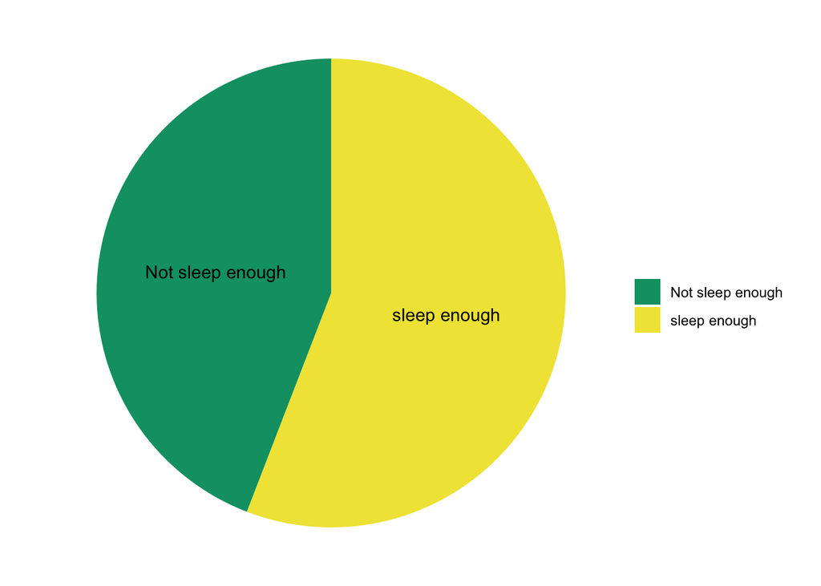

```r
sleep_enough <- sum(combined_data$SleepCon == "Enough")
not_sleep_enough <- sum(combined_data$SleepCon == "Not Enough")
total_sleepcon <- sleep_enough + not_sleep_enough
sep = sleep_enough / total_sleepcon
nsep = not_sleep_enough / total_sleepcon
sleep_percent <- c(sep,nsep)
spdf <- data.frame(category = c("sleep enough","Not sleep enough" ),sleep_percent)

ggplot(data = spdf , aes(x = "",y = sleep_percent,fill = category)) +
  geom_bar(stat = "identity")+
  scale_fill_manual(values = c( "#009E73", "#F0E442")) +
  coord_polar(theta = "y") +
  theme_void() +
  labs(fill="") +
  geom_text(aes(label=category), position=position_stack(vjust=0.5))
```

上圖可以得知有睡超過七小時的使用者佔多數，但人數相差不遠，也就是說使用者睡眠不足的情況頻繁發生。

### 使用者一週中睡眠時間多寡

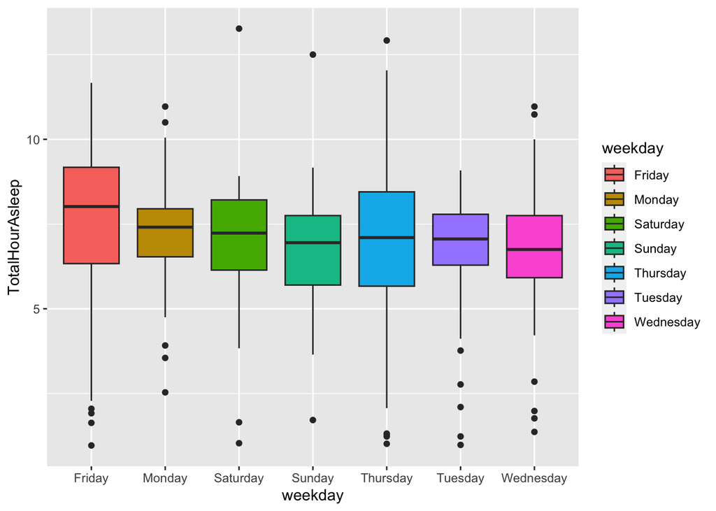

```r
ggplot(data = combined_data) +
  geom_boxplot(mapping = aes(x = weekday , y = TotalHourAsleep , fill = weekday))
```

### 使用者睡眠時間與消耗熱量之間的關係

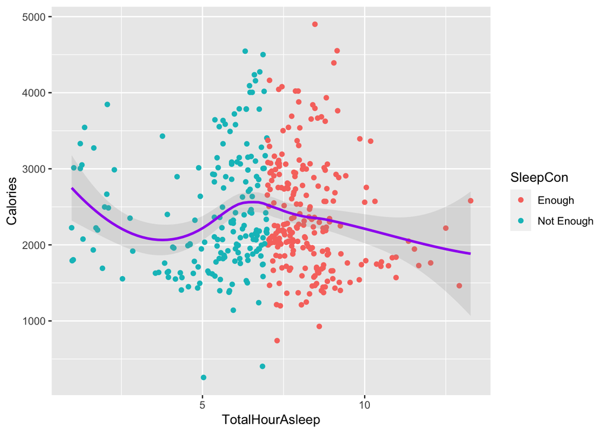

```r
ggplot(data = combined_data) +
  geom_point(mapping = aes(x = TotalHourAsleep , y = Calories,color = SleepCon)) +
  geom_smooth(aes(x = TotalHourAsleep , y = Calories),color = 'purple',alpha = 0.2)
```

上圖可以得知使用者的睡眠時間大多集中在5~10個小時之間，而睡眠時間的多寡與消耗的熱量並沒有太大的關係。

### 活動時間

#### 活動型態佔活動百分比

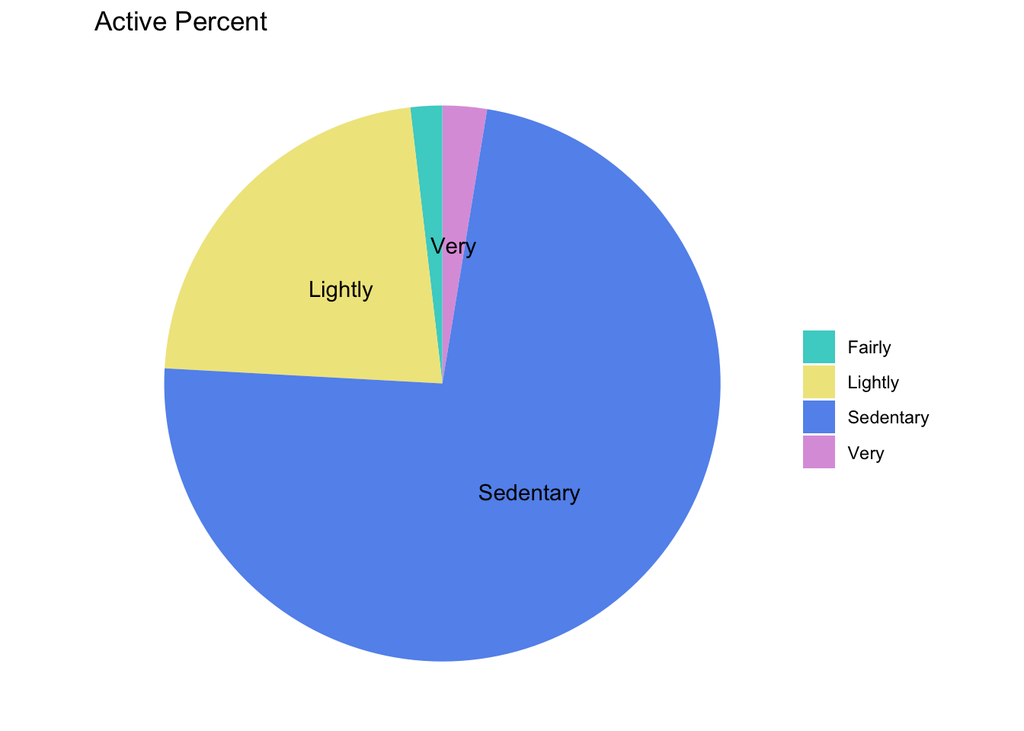

```r
Very_p <- sum(combined_data$VeryActiveMinutes)/sum(combined_data$TotalActiveMinute)
Fairly_p <- sum(combined_data$FairlyActiveMinutes)/sum(combined_data$TotalActiveMinute)
Lightly_p <- sum(combined_data$LightlyActiveMinutes)/sum(combined_data$TotalActiveMinute)
Sedentary_p <- sum(combined_data$SedentaryMinutes)/sum(combined_data$TotalActiveMinute)
Active_percent <- data.frame(category = c("Very","Fairly","Lightly","Sedentary") , value = c(Very_p,Fairly_p,Lightly_p,Sedentary_p))

ggplot(data = Active_percent , aes(x = "",y = value ,fill = category)) +
  geom_bar(stat = "identity")+
  scale_fill_manual(values = c( "#48D1CC", "#F0E68C","#6495ED","#DDA0DD")) +
  coord_polar(theta = "y") +
  theme_void() +
  labs(fill="") +
  geom_text(aes(label=category), position=position_stack(vjust=0.5),check_overlap = "TRUE") +
  labs(title = "Active Percent")
```

可以看到使用者大部分時間都處於久坐狀態或是輕度活動的狀態，較少進行中高強度的運動。

#### 久坐時間與睡眠狀況

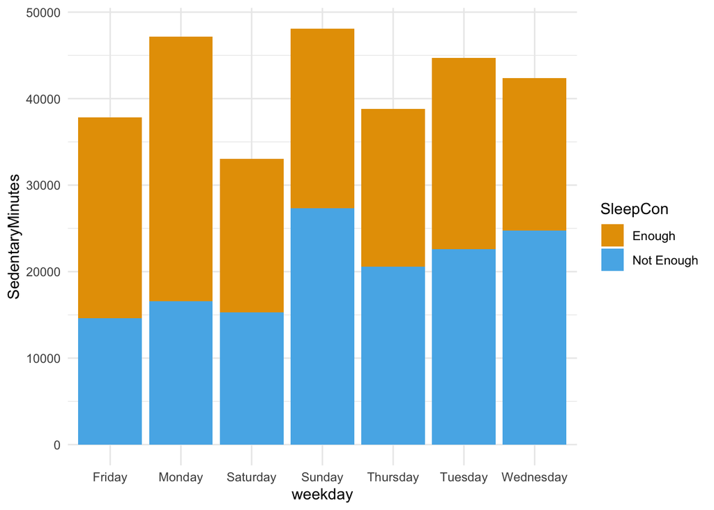

```r
ggplot(data = combined_data, mapping = aes(x = weekday , y = SedentaryMinutes)) +
  geom_col(aes(fill = SleepCon),position = "stack") +
  scale_fill_manual(values = c("#E69F00", "#56B4E9", "#009E73", "#F0E442", "#0072B2")) +
  theme_minimal()
```

#### 週一到週日高強度活動的時間

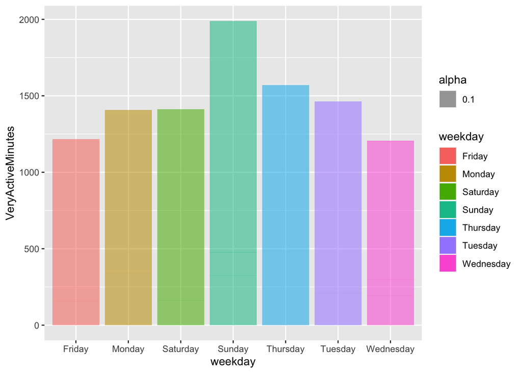

```r
ggplot(data = combined_data) +
  geom_col(mapping = aes(x =weekday,y = VeryActiveMinutes,fill = weekday,alpha = 0.1))
```

#### 週一到週日高強度活動的距離

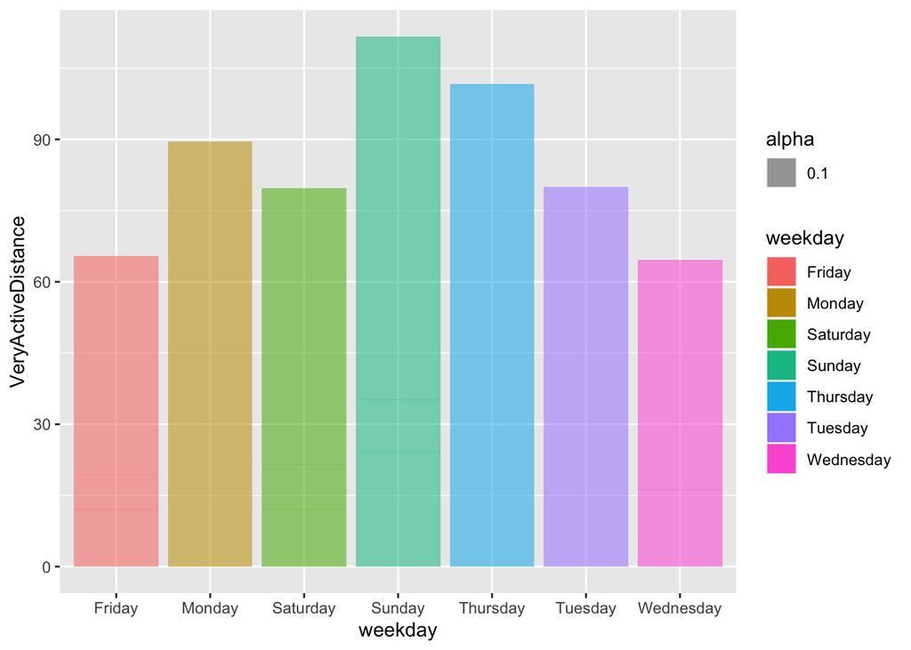

```r
ggplot(data = combined_data) +
  geom_col(mapping = aes(x =weekday,y = VeryActiveDistance,fill = weekday,alpha = .1))
```

### 消耗熱量分析

#### 移動步數與消耗熱量的關係

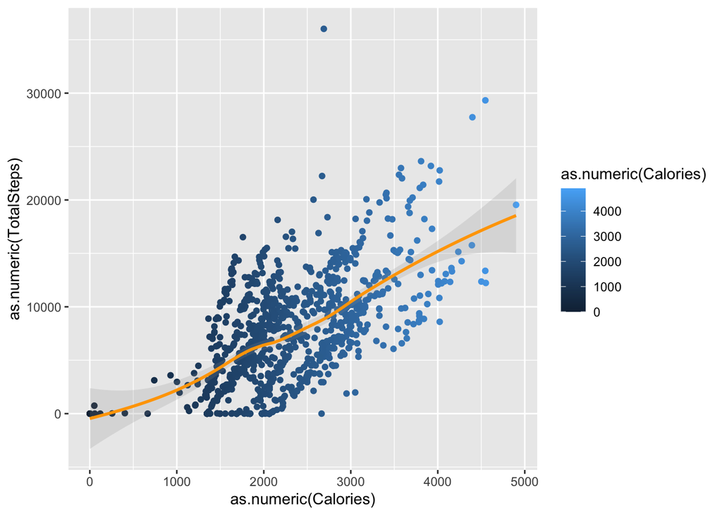

```r
ggplot(data = Active , aes(x = as.numeric(Calories) , y =as.numeric(TotalSteps))) +
                  geom_point(mapping = aes(color =as.numeric(Calories))) +
                  geom_smooth(color = 'orange',alpha = 0.2)
```

#### 移動距離與消耗熱量的關係

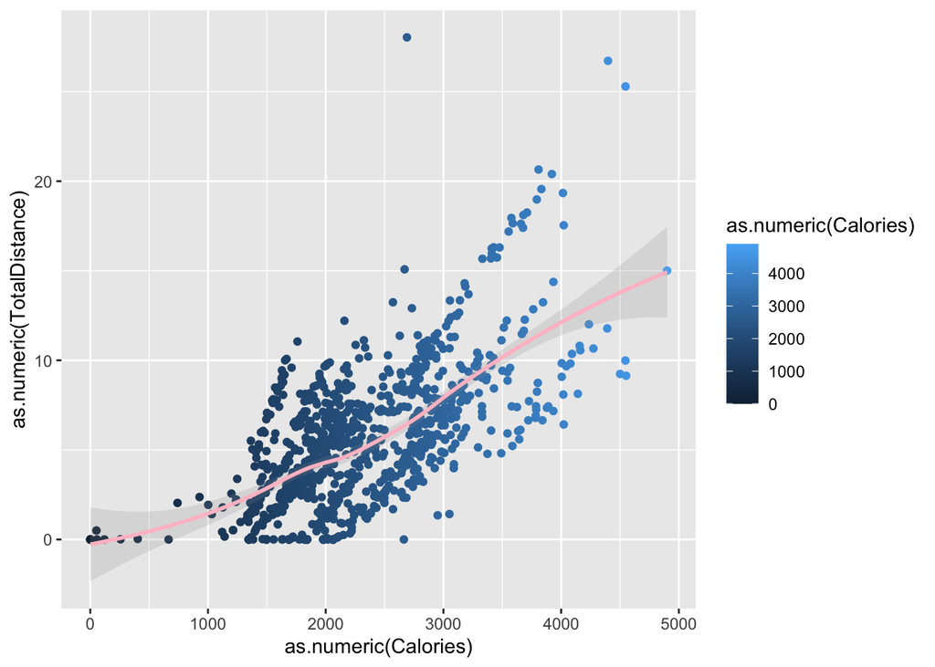

```r
ggplot(data = Active , aes(x = as.numeric(Calories) , y =as.numeric(TotalDistance))) +
                  geom_point(mapping = aes(color =as.numeric(Calories))) +
                  geom_smooth(color = 'pink',alpha = 0.2)
```

經由觀察趨勢線，可以發現移動步數、距離都與消耗的熱量成正向關係。

#### 相關係數表

```r
Picked_Active_1 <- Active %>%
  select(TotalSteps,Calories,TotalDistance)
Cor_Picked_Active_1 <- cor(Picked_Active_1)
head(Cor_Picked_Active_1)
```

```
##               TotalSteps  Calories TotalDistance
## TotalSteps     1.0000000 0.5915681     0.9853688
## Calories       0.5915681 1.0000000     0.6449619
## TotalDistance  0.9853688 0.6449619     1.0000000
```

#### 相關係數圖

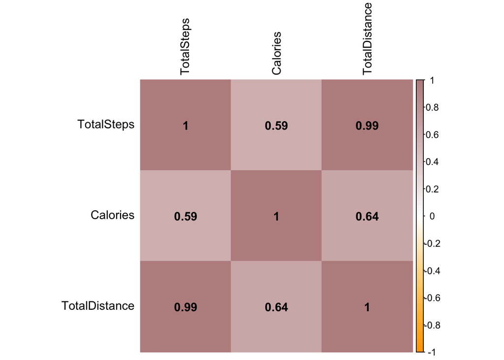

```r
library(corrplot)
corrplot(Cor_Picked_Active_1,
         tl.col = "black",
         method = "color",
         col = colorRampPalette(c("#ffa500", "#FFFFFF", "#BC8F8F"))(100),
         addCoef.col = "black")
```

## 結論

##### 依照分析的結果，提出幾項可以改善的建議：

1. 針對使用者的睡眠時間進行優化，設定獎勵機制或是睡眠提醒促使使用者增加睡眠時間。
2. 使用者較少進行中高強度的運動，導致這結果的主要原因除了使用者不喜歡運動之外，另一個原因可能是因為裝置的關係，一般而言，在進行球類等高強度運動時，大多運動員會將佩戴型裝置拔下，因此公司可以研發別種型態的裝置類型。
3. 與健身房、舞蹈教室等運動課程合作推出優惠方案，鼓勵進行中高強度運動，並在App放置廣告以及推廣運動的優點。